# simstudy_2

Mirah

2025-03-02

## Design Simulation study 2

### Methods

For this simulation, robust regression was used to mitigate the influence of outliers and heavy-tailed distributions. It is useful when ordinary least squares assumptions don’t hold up. Specifically, MM-estimation was performed because this method is useful when handling correlated and non-normal data. The model works by using two steps. The first step is an initial robust estimation with $\beta$ of high resistance to outliers, and the second step involves refining the estimate using a robust lost function. This form of regression downweigns the influence of outliers and works well with skewed data. MM-estimation robust regressing has a high breakdown point compared to other regression models, meaning a high fraction of outliers for which a model won’t break down. Data generation was done via by creating a function from the t-Copula code used in parts 1 and 2 of this study. To summarize, this function used a block-diagonal correlation structure, created a heavy tailed distribution, and sets realistic bounds for the predictors and outcomes. The simulation scenarios are outlined in the table below. Table : Simulation Scenarios

[output not shown]

$$\hat{\beta} = \arg\min_{\beta} \sum_{i=1}^{n} \rho \left( \frac{y_i -
x_i^\top \beta}{\hat{\sigma}} \right)$$
$y_i$ : dependent variable $x_i$ : predictor variable $\beta$ : regression coefficients $\sigma$ : robust estimate of residual standard deviation $\rho$: Robust loss function

Original Data & Robust Regression

```
##
## Call:
## lmrob(formula = glucose ~ blood_pressure + cholesterol + bmi, data = original_data)
##  \--> method = "MM"
## Residuals:
##     Min      1Q  Median      3Q     Max
## -27.182  -8.540   0.429   5.543  27.955
##
## Coefficients:
##                Estimate Std. Error t value Pr(>|t|)
## (Intercept)    -0.08607    1.17675  -0.073    0.942
## blood_pressure  0.13983    0.18075   0.774    0.441
## cholesterol     0.26691    0.05351   4.988 2.71e-06 ***
## bmi            -0.38584    0.52081  -0.741    0.461
## ---
## Signif. codes:  0 '***' 0.001 '**' 0.01 '*' 0.05 '.' 0.1 ' ' 1
##
## Robust residual standard error: 10.78
## Multiple R-squared:  0.2158, Adjusted R-squared:  0.1913
## Convergence in 14 IRWLS iterations
##
## Robustness weights:
##  8 weights are ~= 1. The remaining 92 ones are summarized as
##    Min. 1st Qu.  Median    Mean 3rd Qu.    Max.
##  0.4811  0.8679  0.9429  0.9005  0.9908  0.9986
## Algorithmic parameters:
##        tuning.chi                bb        tuning.psi        refine.tol
##         1.548e+00         5.000e-01         4.685e+00         1.000e-07
##           rel.tol         scale.tol         solve.tol          zero.tol
##         1.000e-07         1.000e-10         1.000e-07         1.000e-10
##       eps.outlier             eps.x warn.limit.reject warn.limit.meanrw
##         1.000e-03         1.316e-10         5.000e-01         5.000e-01
##      nResample         max.it       best.r.s       k.fast.s          k.max
##            500             50              2              1            200
##    maxit.scale      trace.lev            mts     compute.rd fast.s.large.n
##            200              0           1000              0           2000
##                   psi           subsampling                   cov
##            "bisquare"         "nonsingular"         ".vcov.avar1"
## compute.outlier.stats
##                  "SM"
## seed : int(0)
```

Larger Sample Size

```
##
## Call:
## lmrob(formula = glucose ~ blood_pressure + cholesterol + bmi, data = large_data)
##  \--> method = "MM"
## Residuals:
##      Min       1Q   Median       3Q      Max
## -40.4063  -6.8133   0.6225   6.4705  74.1634
##
## Coefficients:
##                 Estimate Std. Error t value Pr(>|t|)
## (Intercept)    -0.271357   0.478200  -0.567    0.571
## blood_pressure -0.008212   0.064991  -0.126    0.900
## cholesterol     0.298226   0.025069  11.896   <2e-16 ***
## bmi            -0.137560   0.216785  -0.635    0.526
## ---
## Signif. codes:  0 '***' 0.001 '**' 0.01 '*' 0.05 '.' 0.1 ' ' 1
##
## Robust residual standard error: 9.956
## Multiple R-squared:  0.3188, Adjusted R-squared:  0.3147
## Convergence in 13 IRWLS iterations
##
## Robustness weights:
##  observation 417 is an outlier with |weight| = 0 ( < 0.0002);
##  46 weights are ~= 1. The remaining 453 ones are summarized as
##    Min. 1st Qu.  Median    Mean 3rd Qu.    Max.
## 0.01969 0.86300 0.95160 0.88700 0.98540 0.99900
## Algorithmic parameters:
##        tuning.chi                bb        tuning.psi        refine.tol
##         1.548e+00         5.000e-01         4.685e+00         1.000e-07
##           rel.tol         scale.tol         solve.tol          zero.tol
##         1.000e-07         1.000e-10         1.000e-07         1.000e-10
##       eps.outlier             eps.x warn.limit.reject warn.limit.meanrw
##         2.000e-04         1.585e-10         5.000e-01         5.000e-01
##      nResample         max.it       best.r.s       k.fast.s          k.max
##            500             50              2              1            200
##    maxit.scale      trace.lev            mts     compute.rd fast.s.large.n
##            200              0           1000              0           2000
##                   psi           subsampling                   cov
##            "bisquare"         "nonsingular"         ".vcov.avar1"
## compute.outlier.stats
##                  "SM"
## seed : int(0)
```

Varying Correlation Levels

```
##
## Call:
## lmrob(formula = glucose ~ blood_pressure + cholesterol + bmi, data = high_corr_data)
##  \--> method = "MM"
## Residuals:
##      Min       1Q   Median       3Q      Max
## -19.6905  -5.8329   0.1867   4.4581  19.8947
##
## Coefficients:
##                Estimate Std. Error t value Pr(>|t|)
## (Intercept)    -0.06183    0.82110  -0.075    0.940
## blood_pressure  0.17355    0.14739   1.177    0.242
## cholesterol     0.45574    0.03404  13.390   <2e-16 ***
## bmi            -0.56055    0.50105  -1.119    0.266
## ---
## Signif. codes:  0 '***' 0.001 '**' 0.01 '*' 0.05 '.' 0.1 ' ' 1
##
## Robust residual standard error: 7.542
## Multiple R-squared:  0.6187, Adjusted R-squared:  0.6068
## Convergence in 15 IRWLS iterations
##
## Robustness weights:
##  10 weights are ~= 1. The remaining 90 ones are summarized as
##    Min. 1st Qu.  Median    Mean 3rd Qu.    Max.
##  0.4665  0.8616  0.9449  0.8971  0.9889  0.9988
## Algorithmic parameters:
##        tuning.chi                bb        tuning.psi        refine.tol
##         1.548e+00         5.000e-01         4.685e+00         1.000e-07
##           rel.tol         scale.tol         solve.tol          zero.tol
##         1.000e-07         1.000e-10         1.000e-07         1.000e-10
##       eps.outlier             eps.x warn.limit.reject warn.limit.meanrw
##         1.000e-03         1.266e-10         5.000e-01         5.000e-01
##      nResample         max.it       best.r.s       k.fast.s          k.max
##            500             50              2              1            200
##    maxit.scale      trace.lev            mts     compute.rd fast.s.large.n
##            200              0           1000              0           2000
##                   psi           subsampling                   cov
##            "bisquare"         "nonsingular"         ".vcov.avar1"
## compute.outlier.stats
##                  "SM"
## seed : int(0)
```

```
##
## Call:
## lmrob(formula = glucose ~ blood_pressure + cholesterol + bmi, data = low_corr_data)
##  \--> method = "MM"
## Residuals:
##      Min       1Q   Median       3Q      Max
## -37.8828  -8.1916  -0.3225   7.9376  40.3242
##
## Coefficients:
##                Estimate Std. Error t value Pr(>|t|)
## (Intercept)     0.10097    1.26183   0.080    0.936
## blood_pressure -0.41760    0.25900  -1.612    0.110
## cholesterol     0.10936    0.06949   1.574    0.119
## bmi             0.47778    0.50312   0.950    0.345
##
## Robust residual standard error: 11.6
## Multiple R-squared:  0.1088, Adjusted R-squared:  0.08099
## Convergence in 23 IRWLS iterations
##
## Robustness weights:
##  10 weights are ~= 1. The remaining 90 ones are summarized as
##    Min. 1st Qu.  Median    Mean 3rd Qu.    Max.
##  0.2020  0.8864  0.9513  0.9006  0.9854  0.9987
## Algorithmic parameters:
##        tuning.chi                bb        tuning.psi        refine.tol
##         1.548e+00         5.000e-01         4.685e+00         1.000e-07
##           rel.tol         scale.tol         solve.tol          zero.tol
##         1.000e-07         1.000e-10         1.000e-07         1.000e-10
##       eps.outlier             eps.x warn.limit.reject warn.limit.meanrw
##         1.000e-03         1.562e-10         5.000e-01         5.000e-01
##      nResample         max.it       best.r.s       k.fast.s          k.max
##            500             50              2              1            200
##    maxit.scale      trace.lev            mts     compute.rd fast.s.large.n
##            200              0           1000              0           2000
##                   psi           subsampling                   cov
##            "bisquare"         "nonsingular"         ".vcov.avar1"
## compute.outlier.stats
##                  "SM"
## seed : int(0)
```

Varying Non-Normality Degree

```
##
## Call:
## lmrob(formula = glucose ~ blood_pressure + cholesterol + bmi, data = low_df_data)
##  \--> method = "MM"
## Residuals:
##      Min       1Q   Median       3Q      Max
## -22.3547  -7.0422   0.5774   6.2502  60.4128
##
## Coefficients:
##                Estimate Std. Error t value Pr(>|t|)
## (Intercept)     -1.1692     1.1344  -1.031    0.305
## blood_pressure   0.1494     0.2276   0.656    0.513
## cholesterol      0.3017     0.0592   5.096 1.74e-06 ***
## bmi             -0.5655     0.5660  -0.999    0.320
## ---
## Signif. codes:  0 '***' 0.001 '**' 0.01 '*' 0.05 '.' 0.1 ' ' 1
##
## Robust residual standard error: 10.43
## Multiple R-squared:  0.2835, Adjusted R-squared:  0.2612
## Convergence in 15 IRWLS iterations
##
## Robustness weights:
##  observation 80 is an outlier with |weight| = 0 ( < 0.001);
##  14 weights are ~= 1. The remaining 85 ones are summarized as
##    Min. 1st Qu.  Median    Mean 3rd Qu.    Max.
##  0.2354  0.8228  0.9517  0.8836  0.9832  0.9990
## Algorithmic parameters:
##        tuning.chi                bb        tuning.psi        refine.tol
##         1.548e+00         5.000e-01         4.685e+00         1.000e-07
##           rel.tol         scale.tol         solve.tol          zero.tol
##         1.000e-07         1.000e-10         1.000e-07         1.000e-10
##       eps.outlier             eps.x warn.limit.reject warn.limit.meanrw
##         1.000e-03         1.234e-10         5.000e-01         5.000e-01
##      nResample         max.it       best.r.s       k.fast.s          k.max
##            500             50              2              1            200
##    maxit.scale      trace.lev            mts     compute.rd fast.s.large.n
##            200              0           1000              0           2000
##                   psi           subsampling                   cov
##            "bisquare"         "nonsingular"         ".vcov.avar1"
## compute.outlier.stats
##                  "SM"
## seed : int(0)
```

```
##
## Call:
## lmrob(formula = glucose ~ blood_pressure + cholesterol + bmi, data = high_df_data)
##  \--> method = "MM"
## Residuals:
##       Min        1Q    Median        3Q       Max
## -46.68456  -9.59117  -0.04131   9.64319  27.94771
##
## Coefficients:
##                Estimate Std. Error t value Pr(>|t|)
## (Intercept)      0.5881     1.3410   0.439   0.6620
## blood_pressure   0.2654     0.1504   1.765   0.0808 .
## cholesterol      0.2817     0.1314   2.144   0.0346 *
## bmi             -0.1820     0.8686  -0.210   0.8345
## ---
## Signif. codes:  0 '***' 0.001 '**' 0.01 '*' 0.05 '.' 0.1 ' ' 1
##
## Robust residual standard error: 12.77
## Multiple R-squared:  0.2388, Adjusted R-squared:  0.2151
## Convergence in 27 IRWLS iterations
##
## Robustness weights:
##  11 weights are ~= 1. The remaining 89 ones are summarized as
##    Min. 1st Qu.  Median    Mean 3rd Qu.    Max.
##  0.1527  0.8934  0.9438  0.9065  0.9786  0.9981
## Algorithmic parameters:
##        tuning.chi                bb        tuning.psi        refine.tol
##         1.548e+00         5.000e-01         4.685e+00         1.000e-07
##           rel.tol         scale.tol         solve.tol          zero.tol
##         1.000e-07         1.000e-10         1.000e-07         1.000e-10
##       eps.outlier             eps.x warn.limit.reject warn.limit.meanrw
##         1.000e-03         1.463e-10         5.000e-01         5.000e-01
##      nResample         max.it       best.r.s       k.fast.s          k.max
##            500             50              2              1            200
##    maxit.scale      trace.lev            mts     compute.rd fast.s.large.n
##            200              0           1000              0           2000
##                   psi           subsampling                   cov
##            "bisquare"         "nonsingular"         ".vcov.avar1"
## compute.outlier.stats
##                  "SM"
## seed : int(0)
```

Lower than 4, and the data did not converge

```
##
## Call:
## lmrob(formula = glucose ~ blood_pressure + cholesterol + bmi, data = bmi_data)
##  \--> method = "MM"
## Residuals:
##     Min      1Q  Median      3Q     Max
## -27.182  -8.540   0.429   5.543  27.955
##
## Coefficients:
##                Estimate Std. Error t value Pr(>|t|)
## (Intercept)    -0.08607    1.17675  -0.073  0.94184
## blood_pressure  0.13983    0.18075   0.774  0.44104
## cholesterol     0.26691    0.05351   4.988 2.71e-06 ***
## bmi             1.61416    0.52081   3.099  0.00255 **
## ---
## Signif. codes:  0 '***' 0.001 '**' 0.01 '*' 0.05 '.' 0.1 ' ' 1
##
## Robust residual standard error: 10.78
## Multiple R-squared:  0.3604, Adjusted R-squared:  0.3404
## Convergence in 14 IRWLS iterations
##
## Robustness weights:
##  8 weights are ~= 1. The remaining 92 ones are summarized as
##    Min. 1st Qu.  Median    Mean 3rd Qu.    Max.
##  0.4811  0.8679  0.9429  0.9005  0.9908  0.9986
## Algorithmic parameters:
##        tuning.chi                bb        tuning.psi        refine.tol
##         1.548e+00         5.000e-01         4.685e+00         1.000e-07
##           rel.tol         scale.tol         solve.tol          zero.tol
##         1.000e-07         1.000e-10         1.000e-07         1.000e-10
##       eps.outlier             eps.x warn.limit.reject warn.limit.meanrw
##         1.000e-03         1.316e-10         5.000e-01         5.000e-01
##      nResample         max.it       best.r.s       k.fast.s          k.max
##            500             50              2              1            200
##    maxit.scale      trace.lev            mts     compute.rd fast.s.large.n
##            200              0           1000              0           2000
##                   psi           subsampling                   cov
##            "bisquare"         "nonsingular"         ".vcov.avar1"
## compute.outlier.stats
##                  "SM"
## seed : int(0)
```

Visualizing results

Comparison of Variance and Bias Across Different Scenarios

|  | Scenario | Variance_Intercept | Variance_BloodPressure | Variance_Cholesterol | Variance_BMI | Bias_Glucose |
| --- | --- | --- | --- | --- | --- | --- |
| (Intercept) | Original Data | 1.3847456 | 0.0326690 | 0.0028632 | 0.2712431 | -0.0860716 |
| (Intercept)1 | Larger Sample Size | 0.2286749 | 0.0042238 | 0.0006284 | 0.0469955 | -0.2713566 |
| (Intercept)2 | High Correlation Levels | 0.6742069 | 0.0217245 | 0.0011584 | 0.2510525 | -0.0618269 |
| (Intercept)3 | Low Correlation Levels | 1.5922209 | 0.0670787 | 0.0048294 | 0.2531280 | 0.1009715 |
| (Intercept)4 | High df (Less Non-Normal) | 1.7981480 | 0.0226239 | 0.0172622 | 0.7543848 | 0.5880719 |
| (Intercept)5 | Low df (More Non-Normal) | 1.2867670 | 0.0517943 | 0.0035051 | 0.3203154 | -1.1691976 |
| (Intercept)6 | BMI Effect Model | 1.3847456 | 0.0326690 | 0.0028632 | 0.2712431 | -0.0860716 |

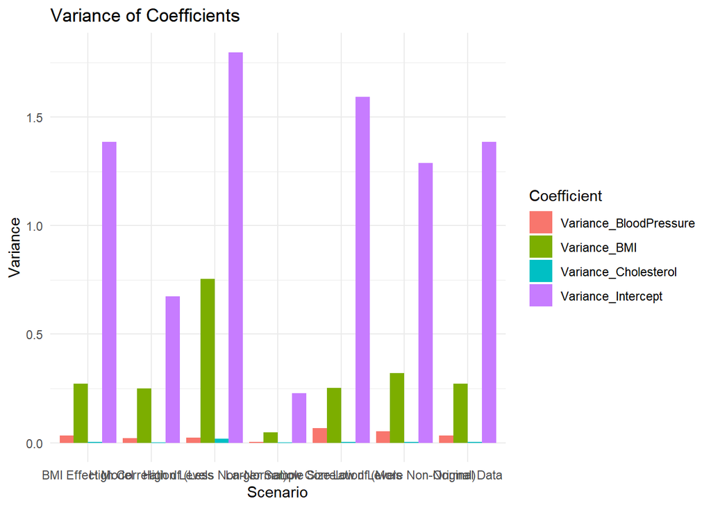

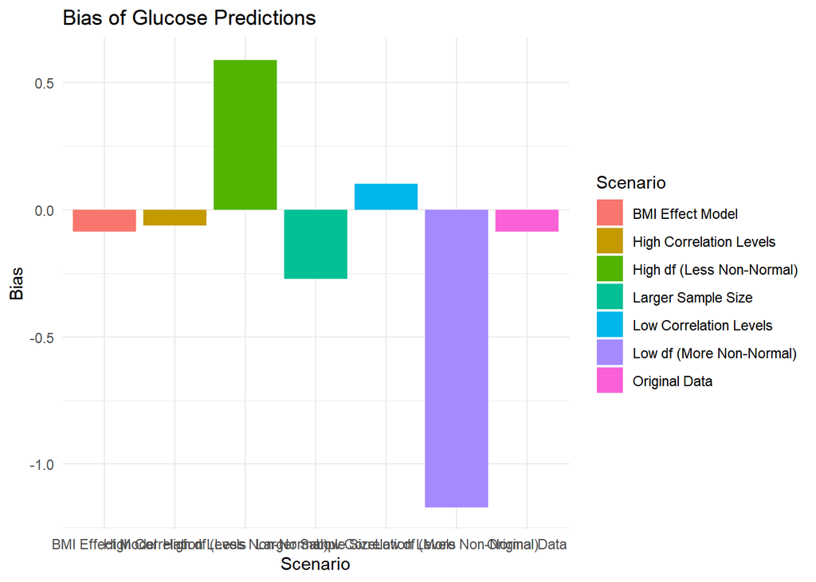

Model Performance and Significant Predictors

| Scenario | R_Squared | Significant_Predictors |
| --- | --- | --- |
| Original Data | 0.2158205 | cholesterol |
| Larger Sample Size | 0.3187857 | cholesterol |
| High Correlation Levels | 0.6186810 | cholesterol |
| Low Correlation Levels | 0.1088416 |  |
| High df (Less Non-Normal) | 0.2388411 | cholesterol |
| Low df (More Non-Normal) | 0.2835416 | cholesterol |
| BMI Effect | 0.3604319 | cholesterol, bmi |

```r
knitr::opts_chunk$set(echo = FALSE)
library(tidyverse)
library(ggplot2)
library(robustbase)
library(copula)
library(Matrix)
library(kableExtra)
#taken from parts 1 and 2 and turned into a function so I can change parapeters in the simulation

#function to generate correlated non-normal data using a t-Copula (used part 2)
generate_t_copula_data <- function(n, nu, rho_mod = NULL) {
  #block-diagonal correlation structure
  block1 <- matrix(c(1, 0.5, 0.5, 1), 2, 2)  #metabolic block
  block2 <- matrix(c(1, 0.4, 0.4, 1), 2, 2)  #cardiovascular block

  #modify correlation for later
  if (!is.null(rho_mod)) {
    block1[1,2] <- block1[2,1] <- rho_mod[1]
    block2[1,2] <- block2[2,1] <- rho_mod[2]
  }

  #correlation matrix
  Sigma <- bdiag(block1, block2)
  Sigma <- as.matrix(nearPD(Sigma)$mat)
  rho_vec <- Sigma[lower.tri(Sigma)]

  #define the t-Copula
  copula_t <- tCopula(param=rho_vec, dim=4, df=nu, dispstr="un")
  U_t <- rCopula(n, copula_t)

  #generate independent heavy-tailed distributions
  mu <- c(100, 200, 25, 120) #the means

# Define upper and lower bounds for each variable
glucose_min <- 32  # minimum plausible fasting glucose level in mg/dL
glucose_max <- 500 # maximum plausible fasting glucose level in mg/dL

cholesterol_min <- 100  # minimum plausible cholesterol level in mg/dL
cholesterol_max <- 300  # maximum plausible cholesterol level in mg/dL

BMI_min <- 15    # minimum plausible BMI
BMI_max <- 40    # maximum plausible BMI

blood_pressure_min <- 90   # minimum plausible systolic blood pressure in mmHg
blood_pressure_max <- 180  # maximum plausible systolic blood pressure in mmHg

  glucose_raw <- scale(rt(10000, df=nu)) * 15 + mu[1]
  cholesterol_raw <- scale(rt(10000, df=nu)) * 25 + mu[2]
  bmi_raw <- scale(rt(10000, df=nu)) * 3 + mu[3]
  blood_pressure_raw <- scale(rt(10000, df=nu)) * 10 + mu[4]

  # Filter out values that fall outside the realistic human limits
glucose <- glucose_raw[glucose_raw >= glucose_min & glucose_raw <= glucose_max]
cholesterol <- cholesterol_raw[cholesterol_raw >= cholesterol_min & cholesterol_raw <= cholesterol_max]
bmi <- bmi_raw[bmi_raw >= BMI_min & bmi_raw <= BMI_max]
blood_pressure <- blood_pressure_raw[blood_pressure_raw >= blood_pressure_min & blood_pressure_raw <= blood_pressure_max]

  #map Copula Uniform Samples Back to Heavy-Tailed Distributions
  data_copula_t <- data.frame(
    glucose = quantile(glucose, probs = U_t[,1]),
    cholesterol = quantile(cholesterol, probs = U_t[,2]),
    bmi = quantile(bmi, probs = U_t[,3]),
    blood_pressure = quantile(blood_pressure, probs = U_t[,4])
  )
  return(data_copula_t)
}

set.seed(2025)

original_data <- generate_t_copula_data(n = 100, nu = 5)
original_data <- original_data %>%
  mutate(across(everything(), ~ . - mean(.)))#centering the data. this prevents the intercept variance from over affecting the data
original_model <- lmrob(glucose ~ blood_pressure + cholesterol + bmi, data = original_data)
summary(original_model) #robust regression using MM
set.seed(2025)

large_data <- generate_t_copula_data(n = 500, nu = 5)
large_data <- large_data %>%
  mutate(across(everything(), ~ . - mean(.)))
large_model <- lmrob(glucose ~ blood_pressure + cholesterol + bmi, data = large_data)
summary(large_model)
set.seed(2025)
high_corr_data <- generate_t_copula_data(n = 100, nu = 5, rho_mod = c(0.8, 0.7))
high_corr_data <- high_corr_data %>%
  mutate(across(everything(), ~ . - mean(.)))
high_corr_model <- lmrob(glucose ~ blood_pressure + cholesterol + bmi, data = high_corr_data)
summary(high_corr_model)

low_corr_data <- generate_t_copula_data(n = 100, nu = 5, rho_mod = c(0.2, 0.1))
low_corr_data <- low_corr_data %>%
  mutate(across(everything(), ~ . - mean(.)))
low_corr_model <- lmrob(glucose ~ blood_pressure + cholesterol + bmi, data = low_corr_data)
summary(low_corr_model)
low_df_data <- generate_t_copula_data(n = 100, nu = 4)
low_df_data <-low_df_data %>%
  mutate(across(everything(), ~ . - mean(.)))
low_df_model <- lmrob(glucose ~ blood_pressure + cholesterol + bmi, data = low_df_data)
summary(low_df_model)

high_df_data <- generate_t_copula_data(n = 100, nu = 6)
high_df_data <- high_df_data %>%
  mutate(across(everything(), ~ . - mean(.)))
high_df_model <- lmrob(glucose ~ blood_pressure + cholesterol + bmi, data = high_df_data)
summary(high_df_model)

set.seed(2025)
bmi_data <- generate_t_copula_data(n = 100, nu = 5)

# Add a strong linear effect of bmi on glucose
bmi_data$glucose <- bmi_data$glucose + 2 * bmi_data$bmi  # Adjust the coefficient (0.5) as needed

#center
bmi_data <- bmi_data %>% mutate(across(everything(), ~ . - mean(.)))

#robust regression model
bmi_model <- lmrob(glucose ~ blood_pressure + cholesterol + bmi, data = bmi_data)
summary(bmi_model)

true_mean_glucose <- 0 #because data was centered around 0

#variance
calculate_variance <- function(model) {
  return(diag(vcov(model)))
}

#bias for glucose
calculate_bias_glucose <- function(model, true_mean_glucose, data) {
  predicted_mean_glucose <- predict(model, newdata = data.frame(
    cholesterol = 0,  # all centered
    bmi = 0,
    blood_pressure = 0
  ))

  #bias = predicted mean - true mean
  bias <- predicted_mean_glucose - true_mean_glucose
  return(bias)
}

#store results
store_results <- function(model, scenario_name, true_mean_glucose, data) {
  variance <- calculate_variance(model)
  bias <- calculate_bias_glucose(model, true_mean_glucose, data)

  data.frame(
    Scenario = scenario_name,
    Variance_Intercept = variance[1],
    Variance_BloodPressure = variance[2],
    Variance_Cholesterol = variance[3],
    Variance_BMI = variance[4],
    Bias_Glucose = bias
  )
}

#store results for each scenario
results <- rbind(
  store_results(original_model, "Original Data", true_mean_glucose, original_data),
  store_results(large_model, "Larger Sample Size", true_mean_glucose, large_data),
  store_results(high_corr_model, "High Correlation Levels", true_mean_glucose, high_corr_data),
  store_results(low_corr_model, "Low Correlation Levels", true_mean_glucose, low_corr_data),
  store_results(high_df_model, "High df (Less Non-Normal)", true_mean_glucose, high_df_data),
  store_results(low_df_model, "Low df (More Non-Normal)", true_mean_glucose, low_df_data),
  store_results(bmi_model, "BMI Effect Model", true_mean_glucose, bmi_data)
)

#results table
kable(results, caption = "Comparison of Variance and Bias Across Different Scenarios")
#variance (for coefficients)
variance_long <- results %>%
  pivot_longer(cols = starts_with("Variance"),
               names_to = "Coefficient",
               values_to = "Variance")

ggplot(variance_long, aes(x = Scenario, y = Variance, fill = Coefficient)) +
  geom_bar(stat = "identity", position = "dodge") +
  labs(title = "Variance of Coefficients", x = "Scenario", y = "Variance") +
  theme_minimal()
#bias (for glucose)
ggplot(results, aes(x = Scenario, y = Bias_Glucose, fill = Scenario)) +
  geom_bar(stat = "identity") +
  labs(title = "Bias of Glucose Predictions", x = "Scenario", y = "Bias") +
  theme_minimal()
library(dplyr)
library(knitr)

# Function to extract R^2 and significant predictors
extract_results <- function(model, scenario_name) {
  # Extract R^2
  r_squared <- summary(model)$r.squared

  # Extract coefficients and p-values
  coef_table <- summary(model)$coefficients
  significant_predictors <- rownames(coef_table)[coef_table[, "Pr(>|t|)"] < 0.05]

  # Remove intercept from significant predictors
  significant_predictors <- significant_predictors[significant_predictors != "(Intercept)"]

  # Combine into a data frame
  data.frame(
    Scenario = scenario_name,
    R_Squared = r_squared,
    Significant_Predictors = paste(significant_predictors, collapse = ", ")
  )
}

results_table <- rbind(
  extract_results(original_model, "Original Data"),
  extract_results(large_model, "Larger Sample Size"),
  extract_results(high_corr_model, "High Correlation Levels"),
  extract_results(low_corr_model, "Low Correlation Levels"),
  extract_results(high_df_model, "High df (Less Non-Normal)"),
  extract_results(low_df_model, "Low df (More Non-Normal)"),
  extract_results(bmi_model, "BMI Effect")
)


kable(results_table, caption = "Model Performance and Significant Predictors")
```

## Refrences

http://dx.doi.org/10.12732/ijpam.v91i3.7